# STAT 331 Group Project

Analyzing the Effect of Health Spending on Life Expectancy

Author

Gracie, Anaïs, Kyle, Ryan

# 1 Project Proposal and Data

The United States is infamous for its exceptionally high healthcare costs, but does this substantial spending translate to longer lifespans? By examining total healthcare expenditure per person (in US dollars) across 188 countries, we aim to uncover its impact on life expectancy.

To address this research question, we will use a linear regression model to quantify the relationship between health spending and life expectancy. Additionally, we will visualize trends over time, explore model fit, and conduct predictive checks to assess the robustness of our model. Our analysis assumes that healthcare spending is a primary driver of life expectancy, though we acknowledge the potential influence of other socioeconomic factors, such as income inequality, education levels, and healthcare infrastructure.

## 1.1 Importing Libraries

```r
library(tidyverse)
library(dplyr)
library(ggplot2)
library(knitr)
library(kableExtra)
library(ggpmisc)
library(DT)
library(broom)
library(htmltools)
library(janitor)
library(ggtext)
library(gridExtra)
library(patchwork)
```

## 1.2 Importing the Datasets

```r
life <- read_csv("data/lex.csv")
health <- read_csv("data/total_health_spending_per_person_us.csv")
```

## 1.3 Data Description

For this data, countries are defined as boundaries as of current geographic boundaries, world history is also shown as if country borders had always been the same as current boundaries.

*Total health spending per person in US$*

This data set ranges from the time period 1995-2010 and shows the average health expenditure per person, expressed in US dollars using the average exchange rate. These values are determined by the World Health Organization (WHO). An average exchange rate is a way to convert from foreign currency to US dollars by dividing the foreign currency amount by an applicable yearly average exchange rate developed by the IRS. Source: https://www.gapminder.org/data/

*Life expectancy, at birth*

This data ranges from a time period of 1800-2100 with the future years being forecasts calculated by the UN. From the years 1800-1970, the main source of this data is from Mattias Lindgen and Klara Johansson. From 1950-2019 the main source of this data is from Institute for Health Metrics and Evaluation (IHME). Life expectancy is defined as the number of years a newborn infant would live if the current mortality rates at different ages were constant. We used the most recent version available to us, Version 14, which was last updated on October 10th 2017. Source: https://www.gapminder.org/data/

## 1.4 Hypothesis

We hypothesize that higher spending on health will increase life expectancy. Past research conducted on similar topics have shown that increases in healthcare related social policies have increased life expectancy in the United States (Reynolds, 2019). Applying these same principles to the aforementioned variables, we believe that increased funding leads to increased life span. To test this hypothesis, we first ensure our data is clean and consistent before conducting analysis.

Source: https://pmc.ncbi.nlm.nih.gov/articles/PMC5739520/

## 1.5 Cleaning the Data

```r
life_exptcy <- life |>
   select("country", 197:212) |>
    pivot_longer(cols = !country,
               names_to = "Year",
               values_to = "Life Expectancy") |>
  rename(Country = country)

health_spd <- health|>
      pivot_longer(cols = !country,
               names_to = "Year",
               values_to = "Spending") |>
   rename(Country = country)
```

## 1.6 Joining the Datasets

```r
data <- inner_join(life_exptcy, health_spd,
                   by = join_by(Country,Year))
head(data) |>
  kable(
      col.names = c("Country", "Year", "Life Expectancy", "Health Spending"),
      caption = "Life Expectancy and Health Spending by Country and Year") |>
  kable_styling(bootstrap_options = c("striped", "hover", "condensed")) |>
  column_spec(1, bold = TRUE)
```

Life Expectancy and Health Spending by Country and Year

| Country | Year | Life Expectancy | Health Spending |
| --- | --- | --- | --- |
| Afghanistan | 1995 | 54.3 | NA |
| Afghanistan | 1996 | 54.7 | NA |
| Afghanistan | 1997 | 54.5 | NA |
| Afghanistan | 1998 | 53.3 | NA |
| Afghanistan | 1999 | 54.7 | NA |
| Afghanistan | 2000 | 54.7 | NA |

## 1.7 Total Number of Countries

```r
country_count <- data |>
summarize(Number_of_Countries = n_distinct(Country))
  kable(country_count)
```

| Number_of_Countries |
| --- |
| 188 |

## 1.8 Number of Missing Data

```r
missing_values <- data |>
  summarize(across(everything(), ~sum(is.na(.x))))
kable(missing_values)
```

| Country | Year | Life Expectancy | Spending |
| --- | --- | --- | --- |
| 0 | 0 | 0 | 32 |

# 2 Linear Regression

In this section we hope to visualize the relationship between the two variables of interest and use a linear regression to model this relationship for further analysis. To do so, the total health spending per person will be our independent variable as we are looking to understand the impact of this variable on life expectancy.

## 2.1 Data Visualizations

### 2.1.1 Data Visualization 1 - The Effect of Health Spending on Life Expectancy

The plot below shows the relationship between Total Health Spending per person in US Dollars and Life Expectancy expressed in years.

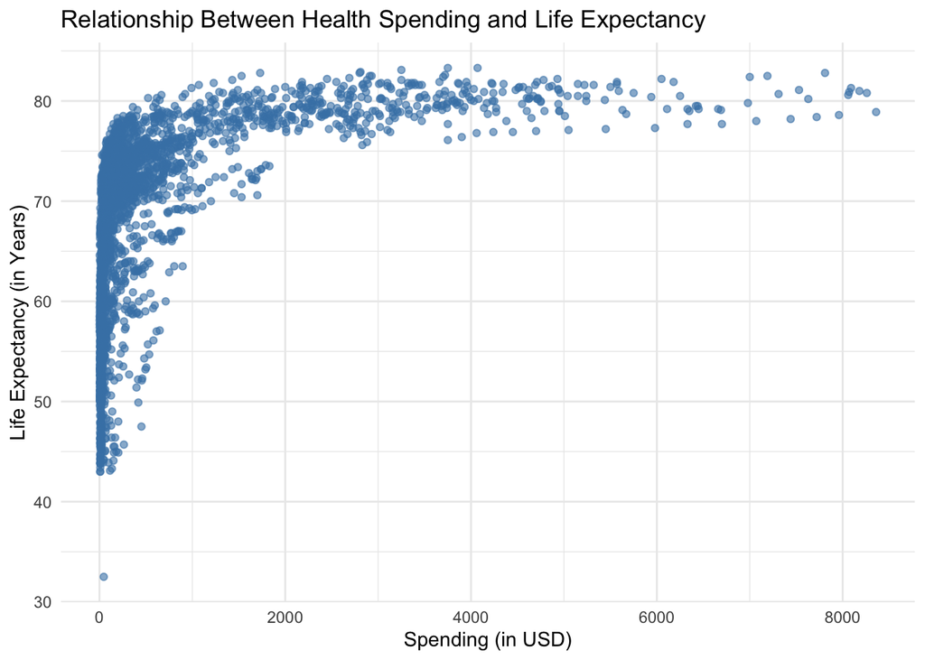

```r
ggplot(data = data,
           aes(x = Spending, y = `Life Expectancy`)) +
      geom_point(color = "steelblue", alpha = 0.6) +
      labs(x = "Spending (in USD)",
           y = "Life Expectancy (in Years)",
           title = "Relationship Between Health Spending and Life Expectancy") +
  theme_minimal()
```

The graph above shows how the plots are mostly concentrated on the left side of the graph. This indicates that the majority of the data shows a lower amount of spending on health care. In addition, it can also be seen that with a lower amount of spending, less than 1000 USD, there is a small number of observations where the life expectancy reaches above 80 years old and majority of the observations fall into the range of 40 to 75 years old. On the other hand, as the spending increases, so does the amount of observations with a recorded life expectancy above 80 years old. An inference could be made stating that with a smaller amount of spending a country dedicates towards healthcare, the lower the expected life expectancy could be.

### 2.1.2 Data Visualization 2 - Average Health Spending vs Life Expectancy Over Time

The following plot analyzes the relationship between the Average Total Health Spending and Average Life Expectancy over time, highlighting how changes in healthcare investment correlate with improvements in longevity. By aggregating data across all countries, this visualization provides a clearer picture of global trends, reducing noise from individual country variations. This visualization helps assess whether increases in spending tend to precede improvements in life expectancy or if they occur simultaneously, strengthening our understanding of causality in this relationship.

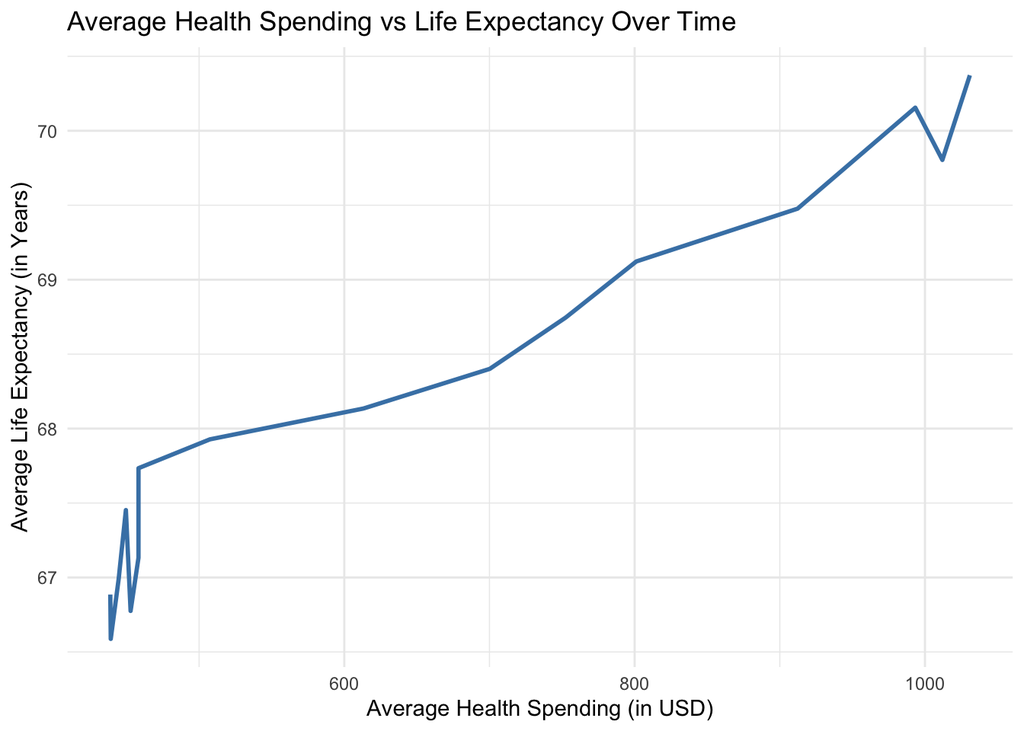

```r
summary_data <- data |>
  group_by(Year) |>
  summarize(mean_spending = mean(Spending, na.rm = TRUE),
            mean_life_expectancy = mean(`Life Expectancy`, na.rm = TRUE))

ggplot(summary_data,
       aes(x = mean_spending,
           y = mean_life_expectancy)) +
  geom_line(color = "steelblue", size = 1) +
  labs(x = "Average Health Spending (in USD)",
       y = "Average Life Expectancy (in Years)",
       title = "Average Health Spending vs Life Expectancy Over Time") +
  theme_minimal()
```

The above figure shows an overall positive relationship between the average amount of health spending and average life expectancy. Compared to the first graph, the range for life expectancy and spending is not as large, given that the averages were taken, rather than individual countries and individual years. From this figure, the inference could be made that with a lower amount of spending, the lower the average life expectancy and with the higher amount of spending, the higher the life expectancy. However, this also raises the question of if health spending is increasing because the population already has a high life expectancy (with a longer lifespan there are more opportunities for health spending).

## 2.2 Linear Regression Model

The data we used to fit the linear model comes from averaging the health spending and life expectancy across all years for each country. This allows us to compare individual countries so we can look for any trends between countries while reducing complexity and volume of data points.

Initial scatterplots revealed a non-linear relationship between health spending and life expectancy, suggesting that spending increases produce diminishing returns. By applying a logarithmic transformation to health spending, we linearize the relationship, making it more suitable for regression analysis.

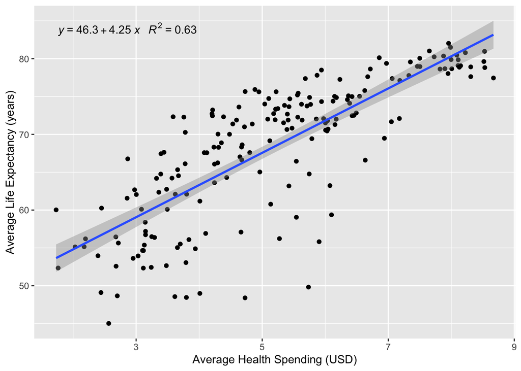

```r
summarized_country <- data |>
  group_by(Country) |>
  summarize(mean_spending = mean(Spending, na.rm = TRUE),
            mean_life_expectancy = mean(`Life Expectancy`, na.rm = TRUE))

summarized_country |>
  ggplot(mapping = aes(x = log(mean_spending),
                       y = mean_life_expectancy)) +
  geom_jitter() +
  geom_smooth(method = "lm") +

  stat_poly_eq(
    aes(label = paste(..eq.label.., ..rr.label.., sep = "~~~")),
    formula = y ~ x,
    parse = TRUE
  ) +

  labs(x = "Average Health Spending (USD)", y = "Average Life Expectancy (years)")
```

```r
life_exptcy_lm <- lm(mean_life_expectancy ~ log(mean_spending),
                     data = summarized_country)
summary(life_exptcy_lm)
```

```
Call:
lm(formula = mean_life_expectancy ~ log(mean_spending), data = summarized_country)

Residuals:
    Min      1Q  Median      3Q     Max
-20.860  -2.403   0.886   3.755  10.773

Coefficients:
                   Estimate Std. Error t value Pr(>|t|)
(Intercept)         46.2992     1.3012   35.58   <2e-16 ***
log(mean_spending)   4.2524     0.2397   17.74   <2e-16 ***
---
Signif. codes:  0 '***' 0.001 '**' 0.01 '*' 0.05 '.' 0.1 ' ' 1

Residual standard error: 5.567 on 186 degrees of freedom
Multiple R-squared:  0.6286,    Adjusted R-squared:  0.6266
F-statistic: 314.7 on 1 and 186 DF,  p-value: < 2.2e-16
```

## 2.3 Model Fit Test

```r
models <- data |>
  janitor::clean_names()

models <- list(
  "Model 1 (Mean Spending, Log)"= lm(mean_life_expectancy ~ log(mean_spending), data = summarized_country),
  "Model 2 (Yearly Spending, Log)"= lm(life_expectancy ~ log(spending), data = models))

final_model<- enframe(models, name = "Model", value = "Fit") |>
  mutate("Variance in Response Values"= map_dbl(Fit, ~ var(model.frame(.x)[,1])),
    "Variance in Fitted Values"= map_dbl(Fit, ~ var(fitted(.x))),
    "Variance in Residuals"= map_dbl(Fit, ~ var(residuals(.x)))) |>
  mutate("R-Squared"= map_dbl(Fit, ~ glance(.x)$r.squared)) |>
  select(-Fit)

datatable(final_model, options = list(pageLength = 10, autoWidth = TRUE),
          caption = HTML("<h3 style='text-align:center; font-weight:bold;'>Model Fit Test Table  </h3>")) |>
  formatRound(columns = c("Variance in Response Values", "Variance in Fitted Values", "Variance in Residuals", "R-Squared"), digits = 3)
```

|  | Model | Variance in Response Values | Variance in Fitted Values | Variance in Residuals | R-Squared |
| --- | --- | --- | --- | --- | --- |
| 1 | Model 1 (Mean Spending, Log) | 82.97502360350119 | 52.154261220841 | 30.82076238266023 | 0.628553737689329 |
| 2 | Model 2 (Yearly Spending, Log) | 84.21247425679998 | 51.07343086546058 | 33.13904339133899 | 0.6064829624850591 |

Comparing two different models, the one that has the best fit will help find the most effective model. The two models that were compared were both simple linear models, but had differences in their variables such as mean spending, log and yearly spending, log. The table above shows the corresponding R^2 values, it shows the simple linear, mean spending, log as the most representative model. This is because the R^2 value is the highest out of all the models, meaning that 63% the variation of the average life expectancy can be explained by the average health spending. This R^2 value is a high enough value to make predictions and inferences with that would be statistically significant. In addition, Model 1 also has the lowest value for variance in residuals, making it the model with the lowest amount that the model does not account for.

Referring back to the first figure, the relationship between the two variables follows a curved line. By taking the log of the spending, helps make it more linear, giving a more accurate R^2 value and a model with a better fit.

# 3 Simulation

## 3.1 Creating a Simulated Dataset

```r
# function to add the normal random error to our predictions
rand_error <- function(x, mean = 0, sd){
  error <- rnorm(length(x), mean = mean, sd = sd)
  return(x + error)
}
```

```r
predicted_exp <- predict(life_exptcy_lm, newdata = summarized_country)
est_sigma <- sigma(life_exptcy_lm)

# simulating the data using the function with seed for reproducibility
set.seed(1234)

sim_response <- rand_error(predicted_exp, sd = est_sigma)
sim_data <- summarized_country |>
  mutate(Simulated_Life_Expectancy = sim_response)

# visualizing the simulated data set
head(sim_data) |>
  kable(
    col.names = c("Country", "Mean Spending", "Mean Life Expectancy", "Simulated Life Expectancy"),
    caption = "Simulated Life Expectancy and Health Spending by Country"
  ) |>
  kable_styling(bootstrap_options = c("striped", "hover", "condensed")) |>
  column_spec(1, bold = TRUE)
```

Simulated Life Expectancy and Health Spending by Country

| Country | Mean Spending | Mean Life Expectancy | Simulated Life Expectancy |
| --- | --- | --- | --- |
| Afghanistan | 25.72222 | 56.48750 | 53.38897 |
| Albania | 132.28125 | 75.93125 | 68.61607 |
| Algeria | 98.77500 | 71.89375 | 71.86628 |
| Andorra | 2105.62500 | 81.01875 | 65.78247 |
| Angola | 51.38875 | 54.88750 | 65.43982 |
| Antigua and Barbuda | 468.18750 | 75.02500 | 75.26346 |

### 3.1.1 Visualizing the Simulated Dataset

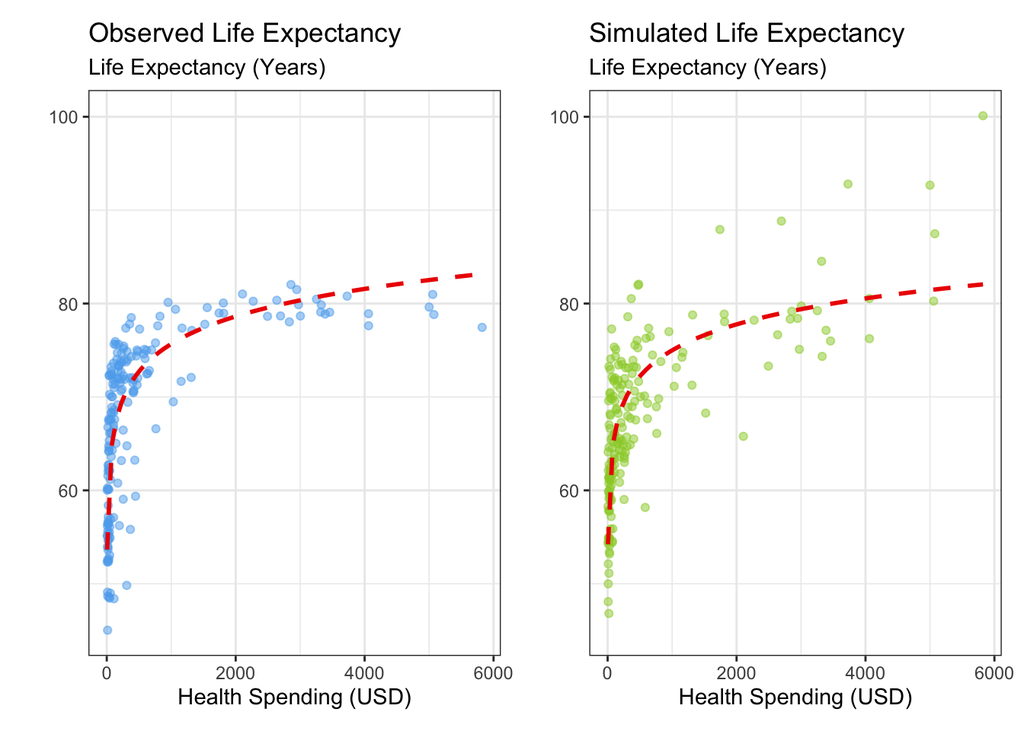

```r
# setting limits for the plot
x_limits <- range(summarized_country$mean_spending, na.rm = TRUE)
y_limits <- range(summarized_country$mean_life_expectancy, sim_data$Simulated_Life_Expectancy, na.rm = TRUE)

# plotting the observed data and fitting a log line
obs_data_plot <- summarized_country |>
  ggplot(aes(y = mean_life_expectancy,
             x = mean_spending)) +
  geom_point(color = "steelblue2", alpha = 0.5) +
  geom_smooth(method = "lm", color = "red2",
              formula = y ~ log(x), se = FALSE, linetype = "dashed") +
  labs(title = "Observed Life Expectancy",
       x = "Health Spending (USD)",
       y = "",
       subtitle = "Life Expectancy (Years)") +
    xlim(x_limits) + ylim(y_limits) +
  theme_bw()

# plotting the simulated data with the same log line for comparison
sim_data_plot <- sim_data |>
  ggplot(aes(y = Simulated_Life_Expectancy,
             x = mean_spending)) +
  geom_point(color = "olivedrab3", alpha = 0.5) +
  geom_smooth(method = "lm", color = "red2",
              formula = y ~ log(x), se = FALSE, linetype = "dashed") +
  labs(title = "Simulated Life Expectancy",
       x = "Health Spending (USD)",
       y = "",
       subtitle = "Life Expectancy (Years)") +
  xlim(x_limits) + ylim(y_limits) +
  theme_bw()

# putting the plots side by side
obs_data_plot + sim_data_plot
```

## 3.2 Generating 1000 Simulated Datasets

```r
set.seed(1234)

sims <- map_dfc(.x = 1:1000,
                .f = ~ tibble(sim = rand_error(predicted_exp,
                                               mean = 0,
                                               sd = est_sigma)))
# replace column names from sims...x to sims_x
colnames(sims) <- colnames(sims) |>
  str_replace(pattern = "\\.\\.\\.",
                  replace = "_")

# add observed response to simulated dataset, dropping NA values if they exist
sims <- summarized_country |>
  filter(!is.na(mean_spending),
         !is.na(mean_life_expectancy)) |>
  select(mean_life_expectancy) |>
  bind_cols(sims)
```

### 3.2.1 Regressing Observed Dataset Against Simulated Datasets

To assess model robustness, we generated 1,000 simulated datasets based on our regression model.

```r
sims_r_squared <- sims |>
  map(.f = ~ lm(mean_life_expectancy ~ .x,
                data = sims)) |>
  map(glance) |>
  map_dbl(~ .x$r.squared)

sims_r_squared <- sims_r_squared[names(sims_r_squared) != "mean_life_expectancy"]
```

### 3.2.2 Plotting Distribution of R<sup>2</sup>

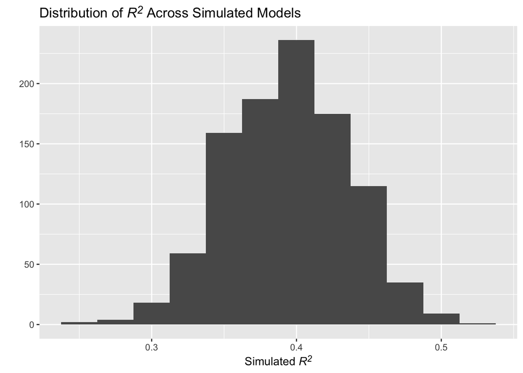

```r
tibble(sims = sims_r_squared) |>
  ggplot(mapping = aes(x = sims)) +
  geom_histogram(binwidth = 0.025) +
  labs(title = expression("Distribution of *R<sup>2</sup>* Across Simulated Models"),
       x = "Simulated *R<sup>2</sup>*",
       y = "") +
  theme(plot.title = element_markdown(),
        axis.title.x = element_markdown())
```

The above graph shows a normal distribution, with most of the R^2 values centering around 0.4, indicating that our model is somewhat helpful in assessing life expectancy based on health spending, but is not necessarily a ’good fit”. If the model performed well, the R^2 values would be mostly distributed around 1. The R^2 value of 0.4 indicates that 40% of the variance in the dependent variable (life expectancy) is explained by the independent variable (health spending amount), suggesting a moderate but not strong relationship.

# 4 Conclusion

Our analysis finds a strong positive relationship between health spending and life expectancy, with 63% of the variation explained by health expenditure. The predictive checks confirm that while the model captures an important portion of the variance, other key factors—such as healthcare accessibility, quality, and broader economic conditions—also play a significant role in determining life expectancy.

Policy Implications: Our findings suggest that governments should prioritize increasing healthcare investment as a means of improving public health outcomes. However, our analysis also highlights the importance of a holistic approach—spending alone is not enough. Policymakers should integrate healthcare investments with broader initiatives in education, sanitation, and preventive medicine to maximize the benefits of increased spending.

Future Research: Given the limitations of our model, further studies could explore additional variables such as income inequality, diet, lifestyle factors, and environmental conditions to develop a more comprehensive understanding of what drives longevity. Exploring non-linear relationships and multi-level modeling approaches could also provide deeper insights into global health trends. Additionally, future research should adjust spending values for inflation and explore time-fixed effects to better account for economic variations over time.